# Homework2

Author

makena

```r
library(nycflights13)
airlines <- airlines
airports <- airports
flights <- flights
planes <- planes
weather <- weather
```

**Question 1**

```r
library(tidytext)
library(dplyr)
flights |>
  unnest_tokens(token, dest) |>
  count(token) |>
  top_n(10, n)
```

```
# A tibble: 10 × 2
   token     n
   <chr> <int>
 1 atl   17215
 2 bos   15508
 3 clt   14064
 4 dca    9705
 5 fll   12055
 6 lax   16174
 7 mco   14082
 8 mia   11728
 9 ord   17283
10 sfo   13331
```

We can see the top 10 flight destinations based on airport code are Atlanta, Boston, Charlotte, Virgina, Fort Lauderdale, Los Angeles, Orlando, Miami, Chicago, and San Francisco. N represents how many flights there were to the specific destination within the “nycflights13” dataset.

**Question 2**

```r
library(tidytext)
library(dplyr)
library(tidyverse)
flights_time <- flights |>
  drop_na(dep_time, arr_time) |>
  mutate(
    dep_time = case_when(
      dep_time < 600  ~ "early morning",
      dep_time < 1200 ~ "morning",
      dep_time < 1800 ~ "afternoon",
      dep_time <= 2400 ~ "evening",
    ),
    arr_time = case_when(
      arr_time < 600  ~ "early morning",
      arr_time < 1200 ~ "morning",
      arr_time < 1800 ~ "afternoon",
      arr_time <= 2400 ~ "evening",
    )
  )
```

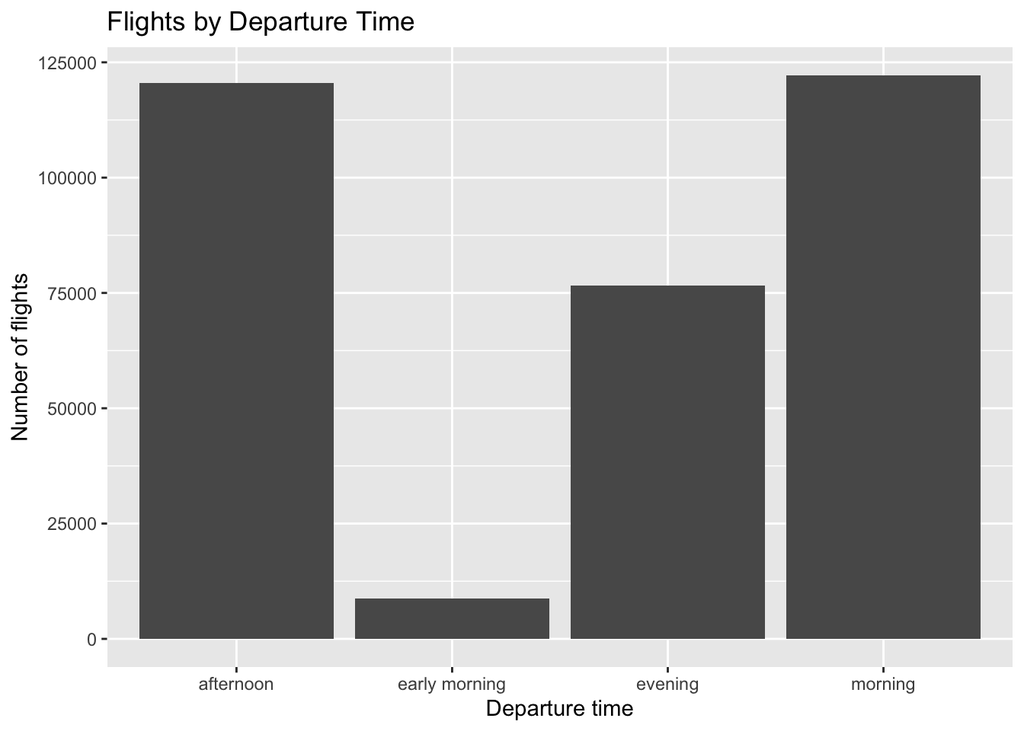

```r
library(ggplot2)
flights_time |>
  ggplot(aes(x = dep_time)) +
  geom_bar() +
  labs(
    x = "Departure time",
    y = "Number of flights",
    title = "Flights by Departure Time"
  )
```

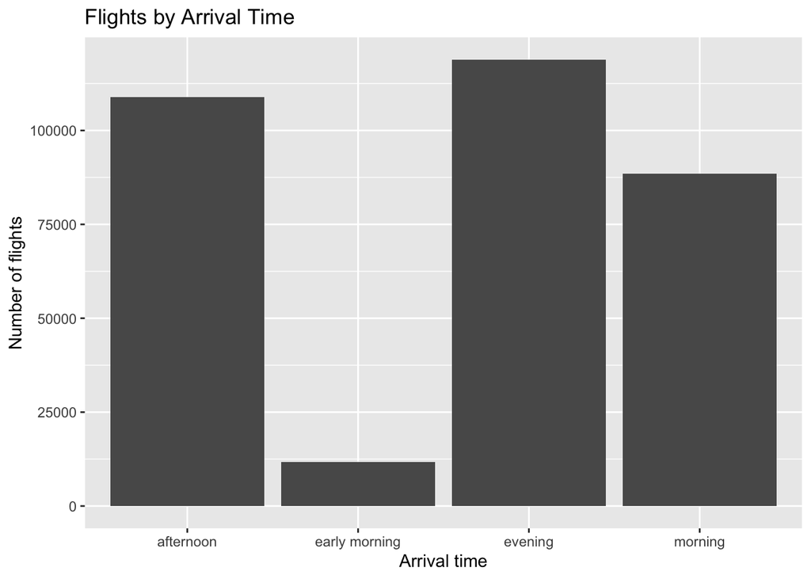

```r
library(ggplot2)
flights_time |>
  ggplot(aes(x = arr_time)) +
  geom_bar() +
  labs(
    x = "Arrival time",
    y = "Number of flights",
    title = "Flights by Arrival Time"
  )
```

```r
library(tidytext)
library(dplyr)
flights_time |>
  summarise(
    red_eye = mean(
      (dep_time == "afternoon" | dep_time == "evening") &
        (arr_time == "early morning" | arr_time == "morning"),
      na.rm = TRUE
    ) * 100
  )
```

```
# A tibble: 1 × 1
  red_eye
    <dbl>
1    3.24
```

3.2% of these total flights followed specific parameters to then be classified as a red eye flight

**Question 3**

```r
library(tidytext)
library(dplyr)
multiple_planes <- flights |>
  drop_na(tailnum) |>
  group_by(tailnum) |>
  filter(n_distinct(carrier) >1) |>
  distinct(tailnum, carrier) |>
  arrange(tailnum)

multiple_planes
```

```
# A tibble: 34 × 2
# Groups:   tailnum [17]
   tailnum carrier
   <chr>   <chr>
 1 N146PQ  9E
 2 N146PQ  EV
 3 N153PQ  9E
 4 N153PQ  EV
 5 N176PQ  9E
 6 N176PQ  EV
 7 N181PQ  9E
 8 N181PQ  EV
 9 N197PQ  9E
10 N197PQ  EV
# ℹ 24 more rows
```

**Question 4**

```r
library(tidytext)
library(dplyr)
weather |>
  left_join(airports, by = c("origin" = "faa"))
```

```
# A tibble: 26,115 × 22
   origin  year month   day  hour  temp  dewp humid wind_dir wind_speed
   <chr>  <int> <int> <int> <int> <dbl> <dbl> <dbl>    <dbl>      <dbl>
 1 EWR     2013     1     1     1  39.0  26.1  59.4      270      10.4
 2 EWR     2013     1     1     2  39.0  27.0  61.6      250       8.06
 3 EWR     2013     1     1     3  39.0  28.0  64.4      240      11.5
 4 EWR     2013     1     1     4  39.9  28.0  62.2      250      12.7
 5 EWR     2013     1     1     5  39.0  28.0  64.4      260      12.7
 6 EWR     2013     1     1     6  37.9  28.0  67.2      240      11.5
 7 EWR     2013     1     1     7  39.0  28.0  64.4      240      15.0
 8 EWR     2013     1     1     8  39.9  28.0  62.2      250      10.4
 9 EWR     2013     1     1     9  39.9  28.0  62.2      260      15.0
10 EWR     2013     1     1    10  41    28.0  59.6      260      13.8
# ℹ 26,105 more rows
# ℹ 12 more variables: wind_gust <dbl>, precip <dbl>, pressure <dbl>,
#   visib <dbl>, time_hour <dttm>, name <chr>, lat <dbl>, lon <dbl>, alt <dbl>,
#   tz <dbl>, dst <chr>, tzone <chr>
```

```r
flight_weather <- flights |>
  left_join(
    weather,
    by = c("year", "month", "day", "hour", "origin")
  ) |>
  select(origin, flight, dep_delay, wind_speed) |>
  drop_na(dep_delay, wind_speed) |>
  arrange(desc(dep_delay))

flight_weather
```

```
# A tibble: 326,915 × 4
   origin flight dep_delay wind_speed
   <chr>   <int>     <dbl>      <dbl>
 1 JFK        51      1301       4.60
 2 JFK      3535      1137       8.06
 3 EWR      3695      1126       8.06
 4 JFK       177      1014      10.4
 5 JFK      3075      1005      10.4
 6 JFK      2391       960      31.1
 7 LGA      2119       911      10.4
 8 JFK      2007       899      12.7
 9 LGA      2047       898      10.4
10 EWR       172       896       8.06
# ℹ 326,905 more rows
```

I wanted to look at if wind speed had any correlation to the amount of delay - in minutes. From this table, ranked in descending order that wind speed didn’t neccesarily have a true effect on departure delay in minutes. Delays can also be mechanical.

**Question 5**

```r
library(tidytext)
library(dplyr)
weather <- weather |>
  unite(
    weather_id,
    year, month, day, hour, origin,
    remove = FALSE
  )
```

```r
weather |>
  summarise(
    number_duplicated = sum(duplicated(weather_id))
  )
```

```
# A tibble: 1 × 1
  number_duplicated
              <int>
1                 3
```

```r
weather |>
  filter(
    duplicated(weather_id) |
      duplicated(weather_id)
  ) |>
  select(weather_id, time_hour)
```

```
# A tibble: 3 × 2
  weather_id      time_hour
  <chr>           <dttm>
1 2013_11_3_1_EWR 2013-11-03 01:00:00
2 2013_11_3_1_JFK 2013-11-03 01:00:00
3 2013_11_3_1_LGA 2013-11-03 01:00:00
```

There could be duplicated values due to daylight savings time.

```r
library(tidytext)
library(dplyr)
flight_weather <- flights |>
  left_join(
    weather,
    by = c("time_hour", "origin")
  ) |>
  drop_na()
```

**Question 6**

```r
dim(flight_weather)
```

```
[1] 72734    33
```

There is 72,734 rows and 33 columns

```r
head(flight_weather)
```

```
# A tibble: 6 × 33
  year.x month.x day.x dep_time sched_dep_time dep_delay arr_time sched_arr_time
   <int>   <int> <int>    <int>          <int>     <dbl>    <int>          <int>
1   2013       1     1      533            529         4      850            830
2   2013       1     1      554            600        -6      812            837
3   2013       1     1      557            600        -3      709            723
4   2013       1     1      558            600        -2      753            745
5   2013       1     1      559            600        -1      941            910
6   2013       1     1      600            600         0      851            858
# ℹ 25 more variables: arr_delay <dbl>, carrier <chr>, flight <int>,
#   tailnum <chr>, origin <chr>, dest <chr>, air_time <dbl>, distance <dbl>,
#   hour.x <dbl>, minute <dbl>, time_hour <dttm>, weather_id <chr>,
#   year.y <int>, month.y <int>, day.y <int>, hour.y <int>, temp <dbl>,
#   dewp <dbl>, humid <dbl>, wind_dir <dbl>, wind_speed <dbl>, wind_gust <dbl>,
#   precip <dbl>, pressure <dbl>, visib <dbl>
```

```r
tail(flight_weather)
```

```
# A tibble: 6 × 33
  year.x month.x day.x dep_time sched_dep_time dep_delay arr_time sched_arr_time
   <int>   <int> <int>    <int>          <int>     <dbl>    <int>          <int>
1   2013       9    26     1139           1110        29     1452           1430
2   2013       9    26     1141           1145        -4     1457           1456
3   2013       9    26     1151           1150         1     1429           1415
4   2013       9    26     1151           1159        -8     1346           1344
5   2013       9    26     1158           1125        33     1339           1310
6   2013       9    26     1219           1159        20     1543           1514
# ℹ 25 more variables: arr_delay <dbl>, carrier <chr>, flight <int>,
#   tailnum <chr>, origin <chr>, dest <chr>, air_time <dbl>, distance <dbl>,
#   hour.x <dbl>, minute <dbl>, time_hour <dttm>, weather_id <chr>,
#   year.y <int>, month.y <int>, day.y <int>, hour.y <int>, temp <dbl>,
#   dewp <dbl>, humid <dbl>, wind_dir <dbl>, wind_speed <dbl>, wind_gust <dbl>,
#   precip <dbl>, pressure <dbl>, visib <dbl>
```

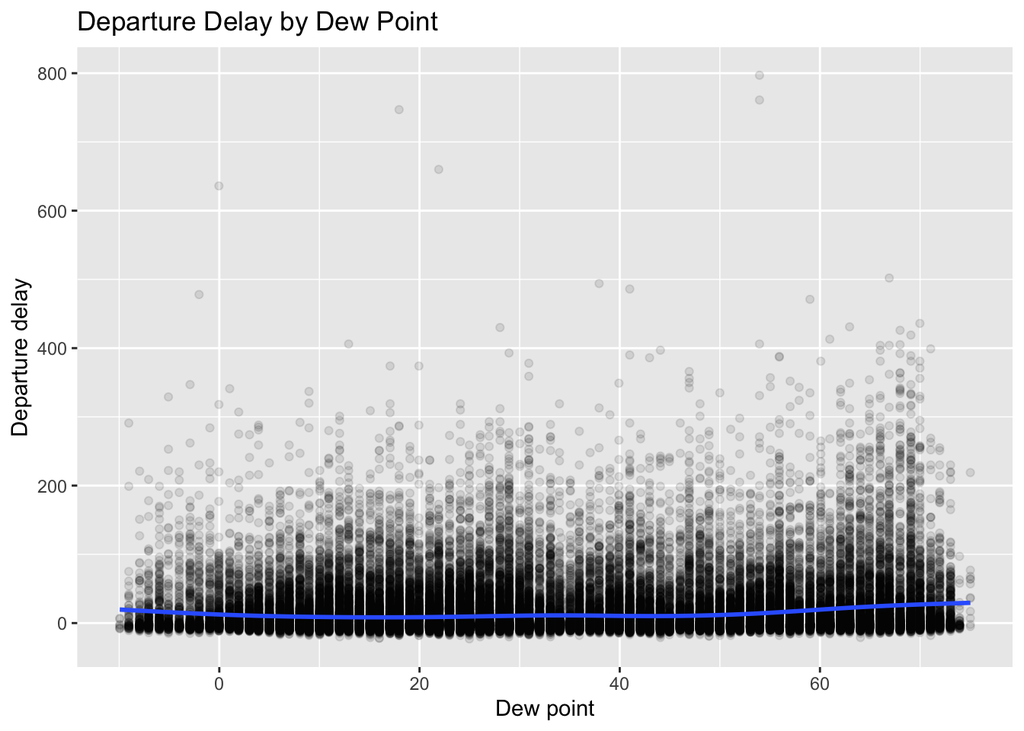

```r
library(ggplot2)
flight_weather |>
  drop_na(dep_delay, dewp) |>
  ggplot(aes(x = dewp, y = dep_delay)) +
  geom_point(alpha = 0.1) +
  geom_smooth() +
  labs(
    x = "Dew point",
    y = "Departure delay",
    title = "Departure Delay by Dew Point"
  )
```

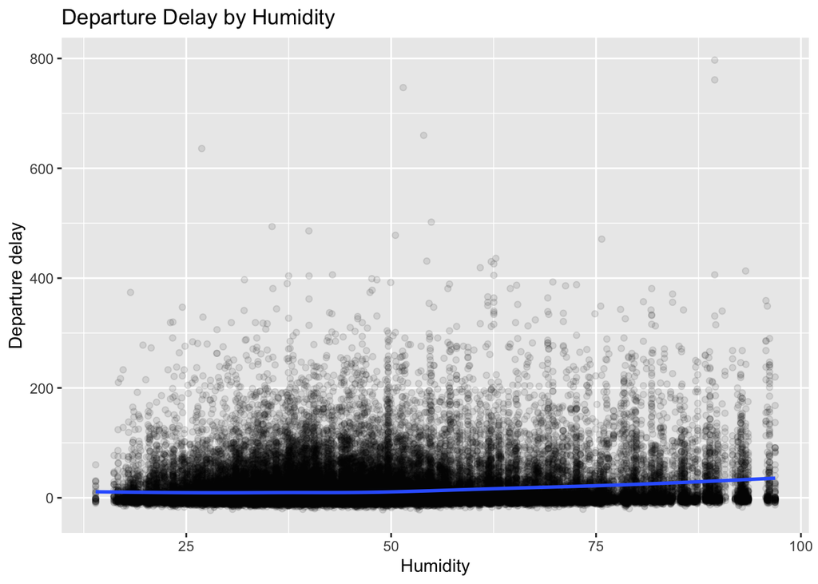

```r
library(ggplot2)
flight_weather |>
  drop_na(dep_delay, humid) |>
  ggplot(aes(x = humid, y = dep_delay)) +
  geom_point(alpha = 0.1) +
  geom_smooth() +
  labs(
    x = "Humidity",
    y = "Departure delay",
    title = "Departure Delay by Humidity"
  )
```

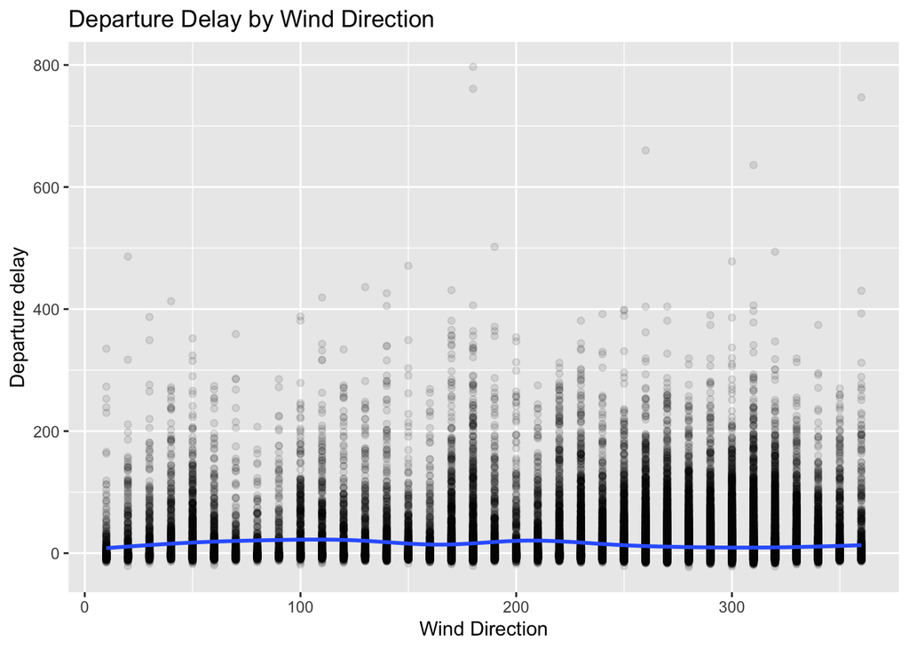

```r
library(ggplot2)
flight_weather |>
  drop_na(dep_delay, wind_dir) |>
  ggplot(aes(x = wind_dir, y = dep_delay)) +
  geom_point(alpha = 0.1) +
  geom_smooth() +
  labs(
    x = "Wind Direction",
    y = "Departure delay",
    title = "Departure Delay by Wind Direction"
  )
```

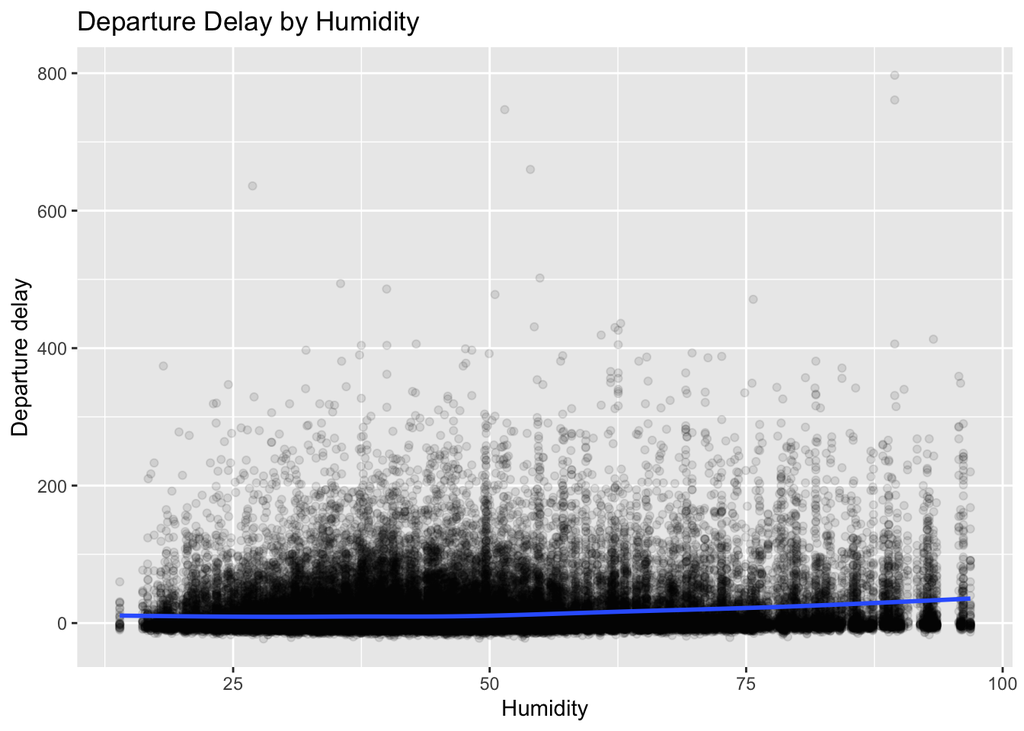

```r
library(ggplot2)
flight_weather |>
  drop_na(dep_delay, humid) |>
  ggplot(aes(x = humid, y = dep_delay)) +
  geom_point(alpha = 0.1) +
  geom_smooth() +
  labs(
    x = "Humidity",
    y = "Departure delay",
    title = "Departure Delay by Humidity"
  )
```

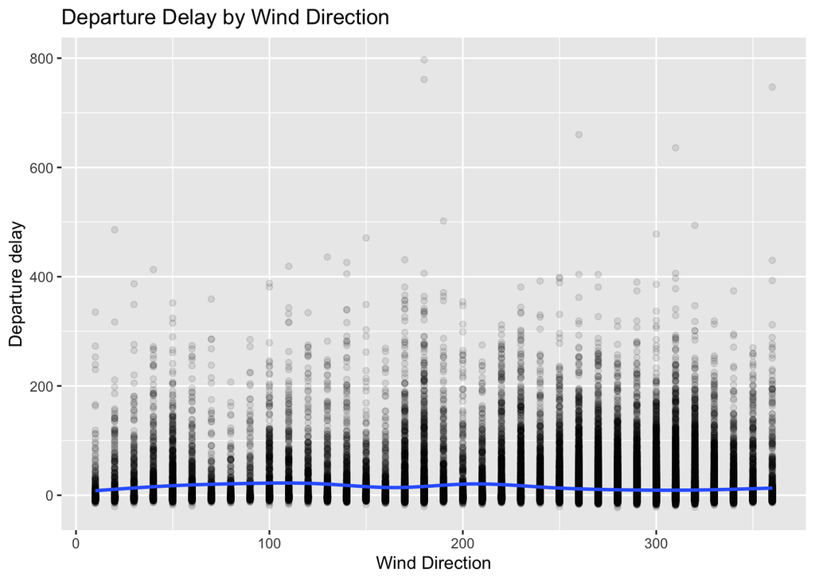

```r
library(ggplot2)
flight_weather |>
  drop_na(dep_delay, wind_dir) |>
  ggplot(aes(x = wind_dir, y = dep_delay)) +
  geom_point(alpha = 0.1) +
  geom_smooth() +
  labs(
    x = "Wind Direction",
    y = "Departure delay",
    title = "Departure Delay by Wind Direction"
  )
```

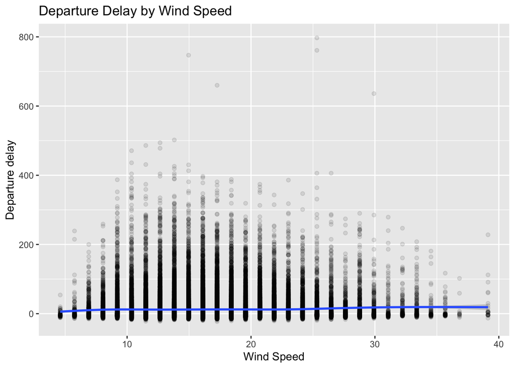

```r
library(ggplot2)
flight_weather |>
  drop_na(dep_delay, wind_speed) |>
  ggplot(aes(x = wind_speed, y = dep_delay)) +
  geom_point(alpha = 0.1) +
  geom_smooth() +
  labs(
    x = "Wind Speed",
    y = "Departure delay",
    title = "Departure Delay by Wind Speed"
  )
```

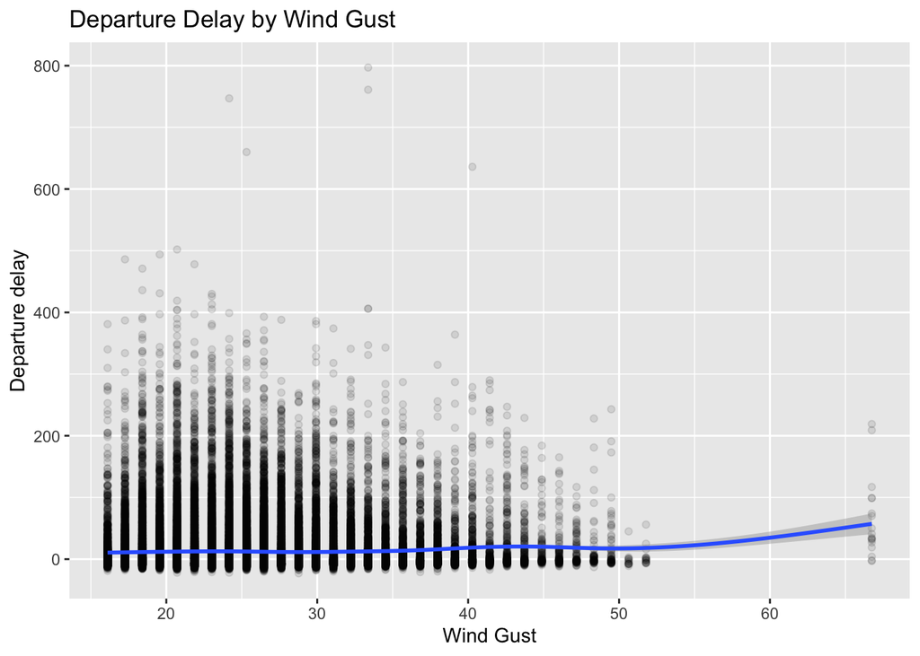

```r
library(ggplot2)
flight_weather |>
  drop_na(dep_delay, wind_gust) |>
  ggplot(aes(x = wind_gust, y = dep_delay)) +
  geom_point(alpha = 0.1) +
  geom_smooth() +
  labs(
    x = "Wind Gust",
    y = "Departure delay",
    title = "Departure Delay by Wind Gust"
  )
```

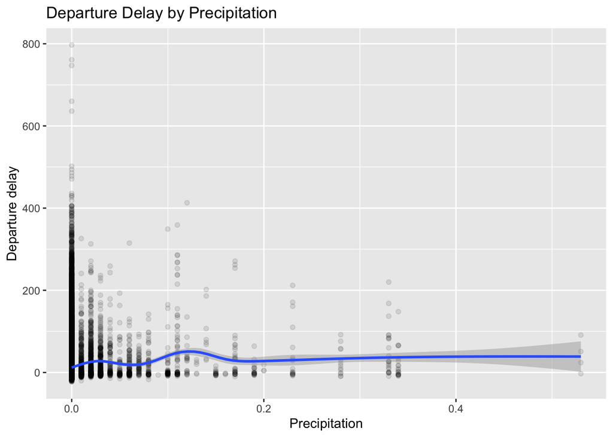

```r
library(ggplot2)
flight_weather |>
  drop_na(dep_delay, precip) |>
  ggplot(aes(x = precip, y = dep_delay)) +
  geom_point(alpha = 0.1) +
  geom_smooth() +
  labs(
    x = "Precipitation",
    y = "Departure delay",
    title = "Departure Delay by Precipitation"
  )
```

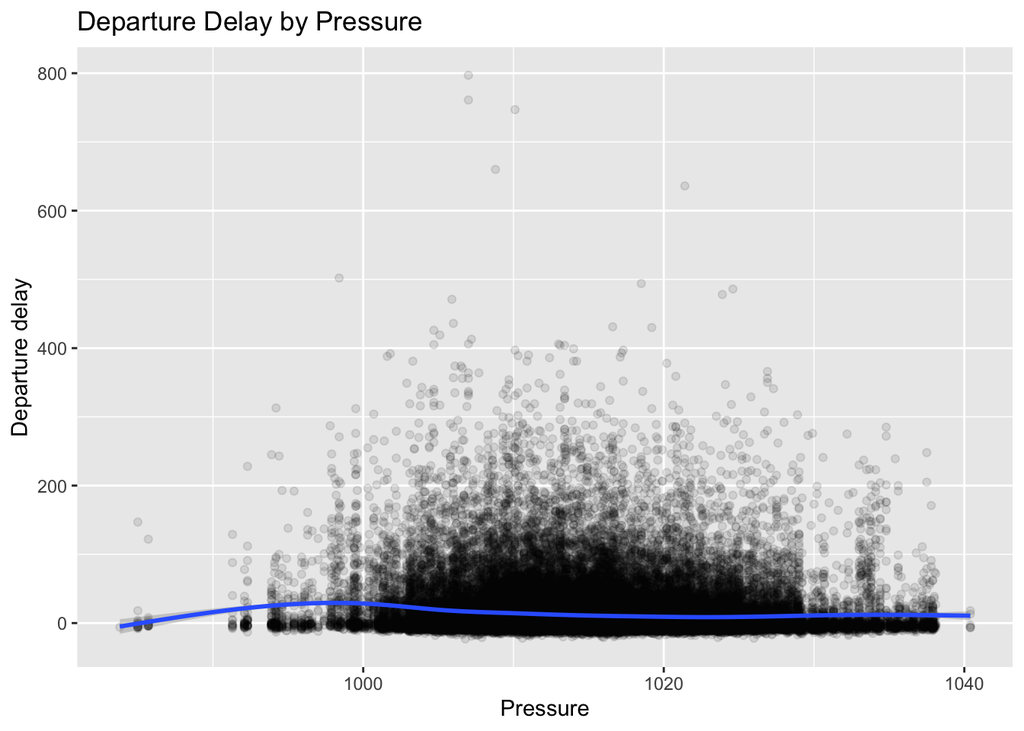

```r
library(ggplot2)
flight_weather |>
  drop_na(dep_delay, pressure) |>
  ggplot(aes(x = pressure, y = dep_delay)) +
  geom_point(alpha = 0.1) +
  geom_smooth() +
  labs(
    x = "Pressure",
    y = "Departure delay",
    title = "Departure Delay by Pressure"
  )
```

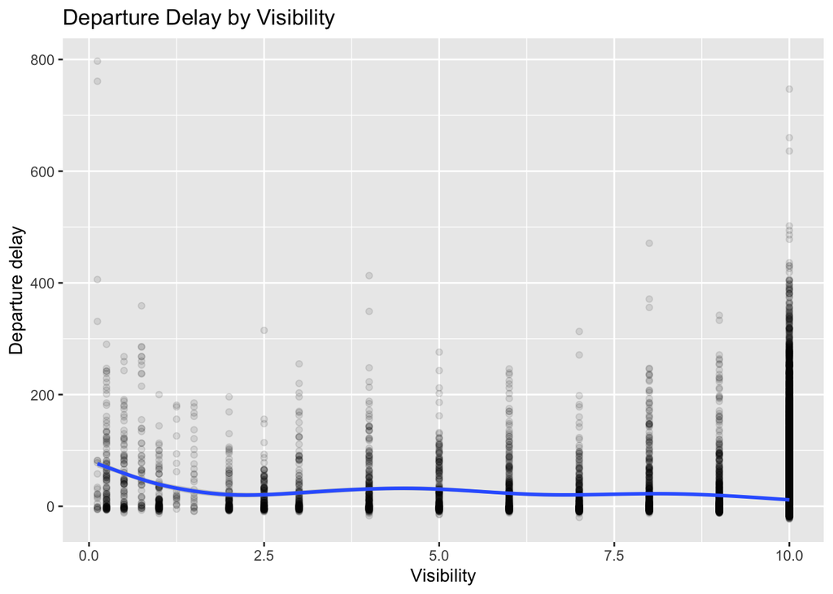

```r
library(ggplot2)
flight_weather |>
  drop_na(dep_delay, visib) |>
  ggplot(aes(x = visib, y = dep_delay)) +
  geom_point(alpha = 0.1) +
  geom_smooth() +
  labs(
    x = "Visibility",
    y = "Departure delay",
    title = "Departure Delay by Visibility"
  )
```

**Group 7**

```r
daily_delays <- flight_weather |>
  group_by(time_hour) |>
  summarise(
    average_delay = mean(dep_delay, na.rm = TRUE)
  ) |>
  arrange(desc(average_delay))

daily_delays
```

```
# A tibble: 2,427 × 2
   time_hour           average_delay
   <dttm>                      <dbl>
 1 2013-02-09 10:00:00          269
 2 2013-09-12 15:00:00          184.
 3 2013-04-19 22:00:00          157
 4 2013-03-08 15:00:00          156.
 5 2013-06-28 20:00:00          154.
 6 2013-07-10 19:00:00          154.
 7 2013-02-09 09:00:00          151
 8 2013-02-09 11:00:00          148.
 9 2013-03-18 19:00:00          141.
10 2013-06-16 22:00:00          140
# ℹ 2,417 more rows
```

```r
daily_origin_delays <- flight_weather |>
  group_by(year.x, month.x, day.x, origin) |>
  summarise(
    average_delay = mean(dep_delay, na.rm = TRUE)
  ) |>
  arrange(desc(average_delay))
```

```
`summarise()` has regrouped the output.
ℹ Summaries were computed grouped by year.x, month.x, day.x, and origin.
ℹ Output is grouped by year.x, month.x, and day.x.
ℹ Use `summarise(.groups = "drop_last")` to silence this message.
ℹ Use `summarise(.by = c(year.x, month.x, day.x, origin))` for per-operation
  grouping (`?dplyr::dplyr_by`) instead.
```

```r
daily_origin_delays
```

```
# A tibble: 762 × 5
# Groups:   year.x, month.x, day.x [309]
   year.x month.x day.x origin average_delay
    <int>   <int> <int> <chr>          <dbl>
 1   2013       6    24 LGA            132.
 2   2013       3     8 EWR            127.
 3   2013       8     8 LGA            126.
 4   2013       6    18 LGA            122.
 5   2013       3     8 LGA            108
 6   2013       6    27 JFK            104.
 7   2013       5    23 EWR             99.0
 8   2013       4    19 JFK             95.8
 9   2013       9    12 JFK             92.5
10   2013       8     8 JFK             91.2
# ℹ 752 more rows
```

The airport that had the worst single day was LGA and it was June 24 2013.

```r
daily_hour_origin_delays <- flight_weather |>
  group_by(month.x, day.x, hour.x, origin) |>
  summarise(
    average_delay = mean(dep_delay, na.rm = TRUE)
  ) |>
  arrange(desc(average_delay))
```

```
`summarise()` has regrouped the output.
ℹ Summaries were computed grouped by month.x, day.x, hour.x, and origin.
ℹ Output is grouped by month.x, day.x, and hour.x.
ℹ Use `summarise(.groups = "drop_last")` to silence this message.
ℹ Use `summarise(.by = c(month.x, day.x, hour.x, origin))` for per-operation
  grouping (`?dplyr::dplyr_by`) instead.
```

```r
daily_hour_origin_delays
```

```
# A tibble: 4,163 × 5
# Groups:   month.x, day.x, hour.x [2,427]
   month.x day.x hour.x origin average_delay
     <int> <int>  <dbl> <chr>          <dbl>
 1       2     9     10 EWR             269
 2       2     9      9 EWR             266
 3       9    12     15 LGA             184.
 4       2     9     11 EWR             177.
 5       7    10     19 EWR             160.
 6       4    19     22 JFK             157
 7       3     8     15 LGA             156.
 8       6    28     20 EWR             154.
 9       4    19     21 EWR             149.
10       7    10     19 LGA             147.
# ℹ 4,153 more rows
```

The worst delay was at EWR airport at 10 am on February 9.

**Question 8**

```r
average_arrival_delay <- flights |>
  group_by(dest) |>
  summarise(
    average_delay = mean(arr_delay, na.rm = TRUE)
  ) |>
  drop_na(average_delay)

airports <- nycflights13::airports |>
  left_join(
    average_arrival_delay,
    by = c("faa" = "dest")
  ) |>
  drop_na(average_delay)
```

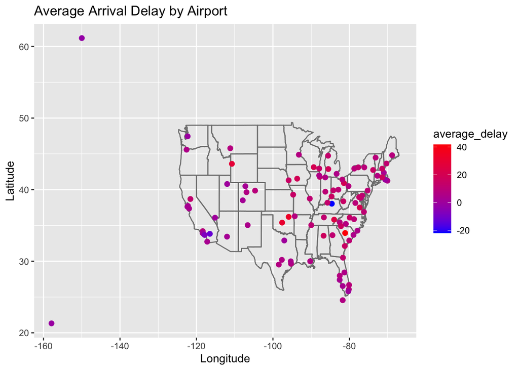

```r
library(ggplot2)
#| fig-width: 20
#| fig-height: 20
airports |>
  ggplot(aes(x = lon, y = lat)) +
  borders("state", color = "gray") +
  geom_point(
    aes(color = average_delay),
    size = 2
  ) +
  scale_color_gradient(
    low = "blue",
    high = "red"
  ) +
  labs(
    title = "Average Arrival Delay by Airport",
    x = "Longitude",
    y = "Latitude",
  )
```

**Question 9**

```r
flight_weather |>
  drop_na(dep_delay, dewp) |>
  summarise(correlation = cor(dep_delay, dewp))
```

```
# A tibble: 1 × 1
  correlation
        <dbl>
1       0.101
```

```r
flight_weather |>
  drop_na(dep_delay, humid) |>
  summarise(correlation = cor(dep_delay, humid))
```

```
# A tibble: 1 × 1
  correlation
        <dbl>
1       0.122
```

```r
flight_weather |>
  drop_na(dep_delay, wind_dir) |>
  summarise(correlation = cor(dep_delay, wind_dir))
```

```
# A tibble: 1 × 1
  correlation
        <dbl>
1     -0.0684
```

```r
flight_weather |>
  drop_na(dep_delay, wind_gust) |>
  summarise(correlation = cor(dep_delay, wind_gust))
```

```
# A tibble: 1 × 1
  correlation
        <dbl>
1      0.0244
```

```r
flight_weather |>
  drop_na(dep_delay, precip) |>
  summarise(correlation = cor(dep_delay, precip))
```

```
# A tibble: 1 × 1
  correlation
        <dbl>
1      0.0484
```

```r
flight_weather |>
  drop_na(dep_delay, pressure) |>
  summarise(correlation = cor(dep_delay, pressure))
```

```
# A tibble: 1 × 1
  correlation
        <dbl>
1     -0.0817
```

```r
flight_weather |>
  drop_na(dep_delay, visib) |>
  summarise(correlation = cor(dep_delay, visib))
```

```
# A tibble: 1 × 1
  correlation
        <dbl>
1     -0.0975
```

the weather phenomena that has the strongest correlation to departure delays is Humidity.

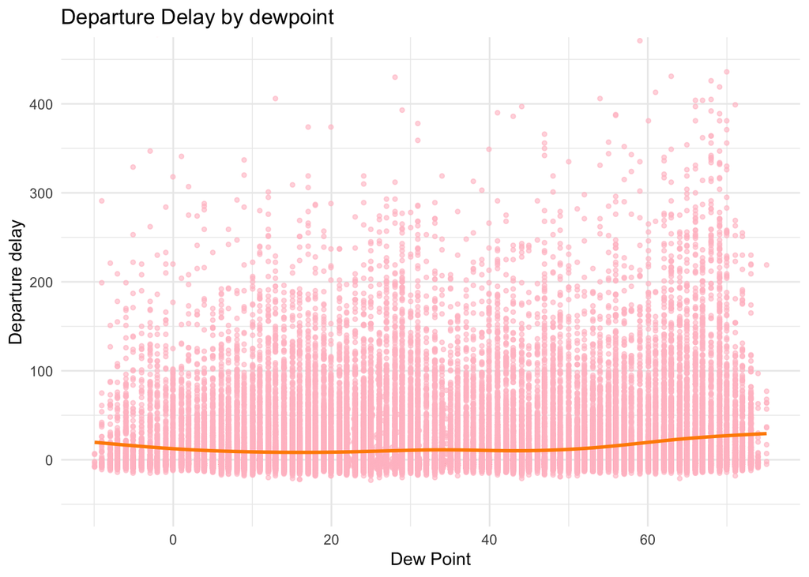

```r
flight_weather |>
  drop_na(dep_delay, dewp) |>
  ggplot(aes(x = dewp, y = dep_delay)) +
  geom_point(
    color = "pink",
    alpha = 0.6,
    size = 1
  ) +
  geom_smooth(
    color = "darkorange",
    se = FALSE
  ) +
  coord_cartesian(ylim = c(-50, 450)) +
  labs(
    title = "Departure Delay by dewpoint",
    x = "Dew Point",
    y = "Departure delay"
  ) +
  theme_minimal()
```

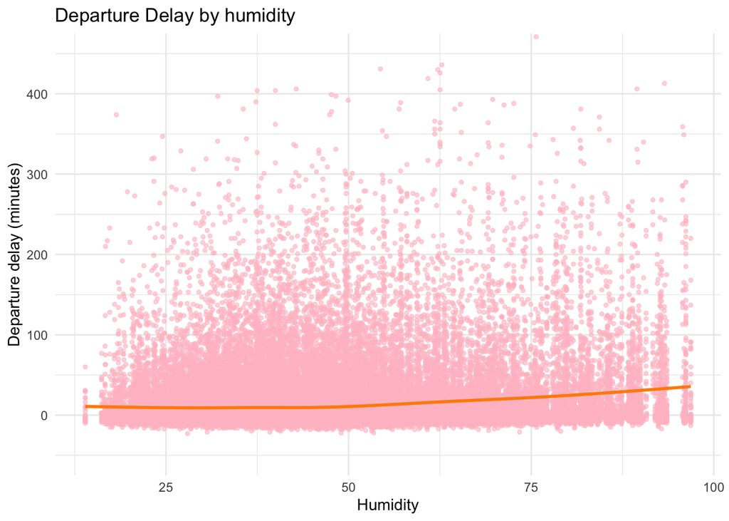

```r
flight_weather |>
  drop_na(dep_delay, humid) |>
  ggplot(aes(x = humid, y = dep_delay)) +
  geom_point(
    color = "pink",
    alpha = 0.6,
    size = 1
  ) +
  geom_smooth(
    color = "darkorange",
    se = FALSE
  ) +
  coord_cartesian(ylim = c(-50, 450)) +
  labs(
    title = "Departure Delay by humidity",
    x = "Humidity",
    y = "Departure delay (minutes)"
  ) +
  theme_minimal()
```

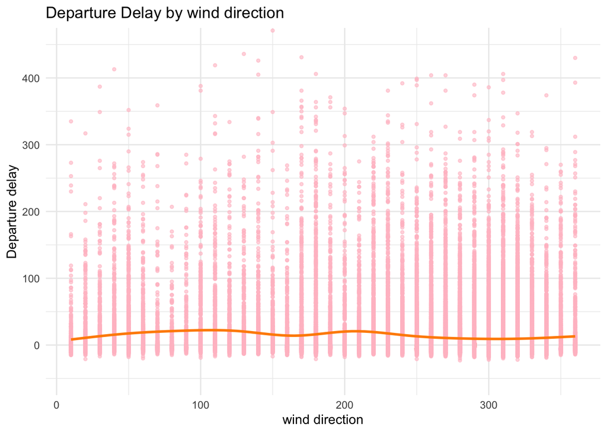

```r
flight_weather |>
  drop_na(dep_delay, wind_dir) |>
  ggplot(aes(x = wind_dir, y = dep_delay)) +
  geom_point(
    color = "pink",
    alpha = 0.6,
    size = 1
  ) +
  geom_smooth(
    color = "darkorange",
    se = FALSE
  ) +
  coord_cartesian(ylim = c(-50, 450)) +
  labs(
    title = "Departure Delay by wind direction",
    x = "wind direction",
    y = "Departure delay"
  ) +
  theme_minimal()
```

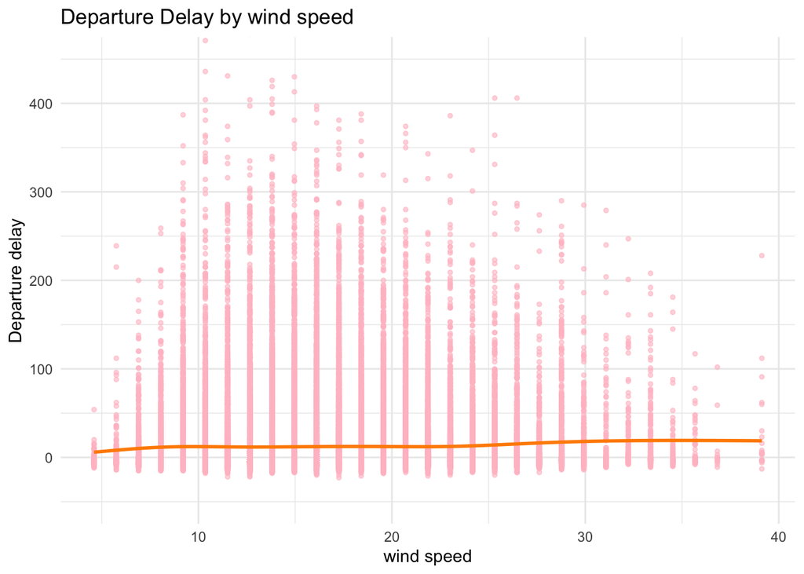

```r
flight_weather |>
  drop_na(dep_delay, wind_speed) |>
  ggplot(aes(x = wind_speed, y = dep_delay)) +
  geom_point(
    color = "pink",
    alpha = 0.6,
    size = 1
  ) +
  geom_smooth(
    color = "darkorange",
    se = FALSE
  ) +
  coord_cartesian(ylim = c(-50, 450)) +
  labs(
    title = "Departure Delay by wind speed",
    x = "wind speed",
    y = "Departure delay"
  ) +
  theme_minimal()
```

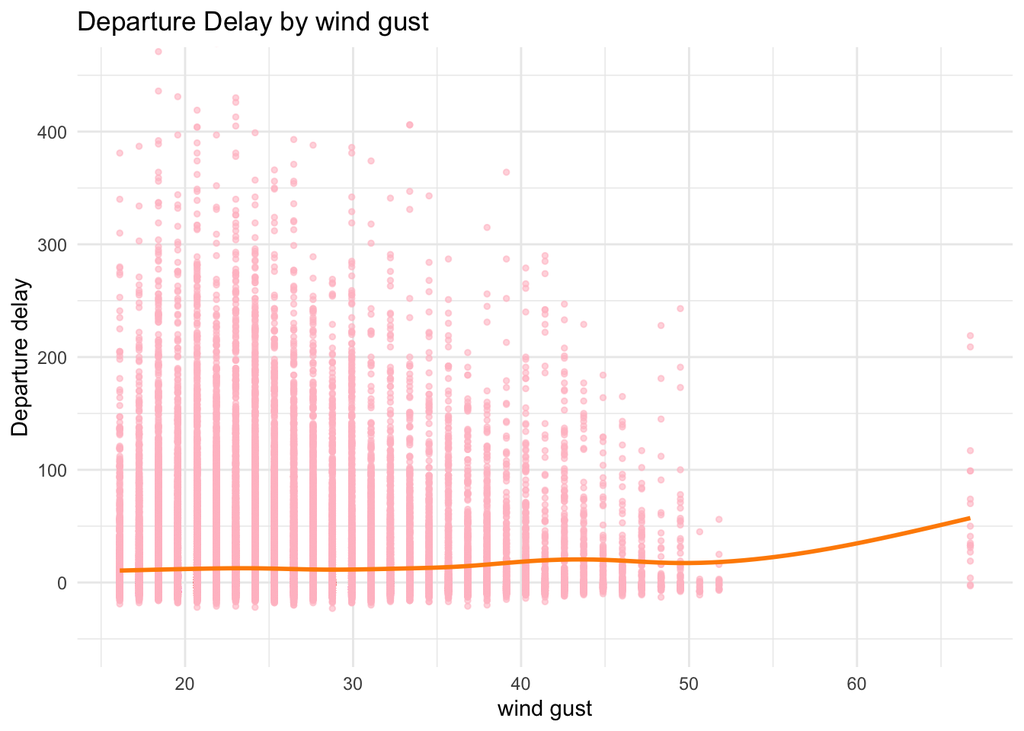

```r
flight_weather |>
  drop_na(dep_delay, wind_gust) |>
  ggplot(aes(x = wind_gust, y = dep_delay)) +
  geom_point(
    color = "pink",
    alpha = 0.6,
    size = 1
  ) +
  geom_smooth(
    color = "darkorange",
    se = FALSE
  ) +
  coord_cartesian(ylim = c(-50, 450)) +
  labs(
    title = "Departure Delay by wind gust",
    x = "wind gust",
    y = "Departure delay"
  ) +
  theme_minimal()
```

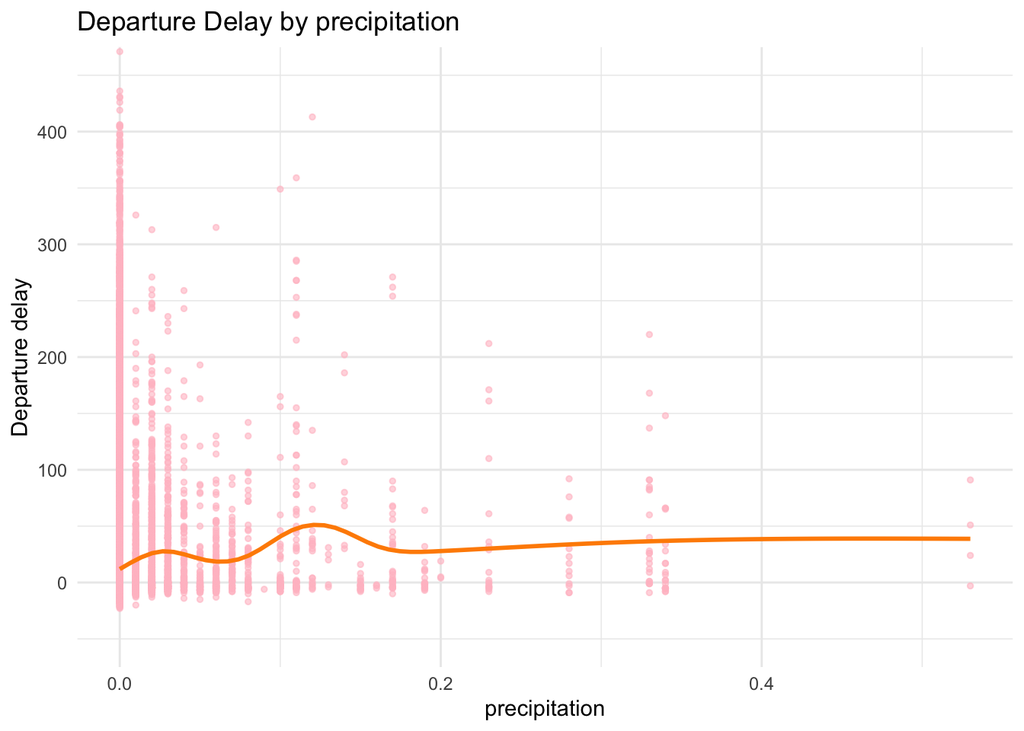

```r
flight_weather |>
  drop_na(dep_delay, precip) |>
  ggplot(aes(x = precip, y = dep_delay)) +
  geom_point(
    color = "pink",
    alpha = 0.6,
    size = 1
  ) +
  geom_smooth(
    color = "darkorange",
    se = FALSE
  ) +
  coord_cartesian(ylim = c(-50, 450)) +
  labs(
    title = "Departure Delay by precipitation",
    x = "precipitation",
    y = "Departure delay"
  ) +
  theme_minimal()
```

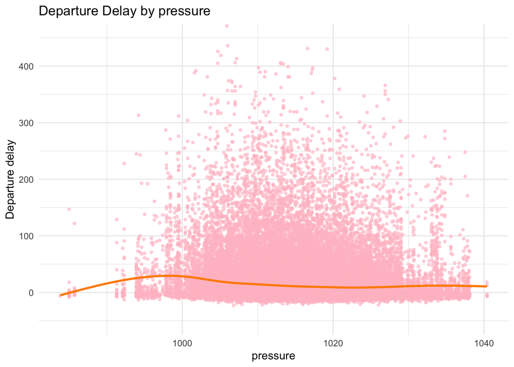

```r
flight_weather |>
  drop_na(dep_delay, pressure) |>
  ggplot(aes(x = pressure, y = dep_delay)) +
  geom_point(
    color = "pink",
    alpha = 0.6,
    size = 1
  ) +
  geom_smooth(
    color = "darkorange",
    se = FALSE
  ) +
  coord_cartesian(ylim = c(-50, 450)) +
  labs(
    title = "Departure Delay by pressure",
    x = "pressure",
    y = "Departure delay"
  ) +
  theme_minimal()
```

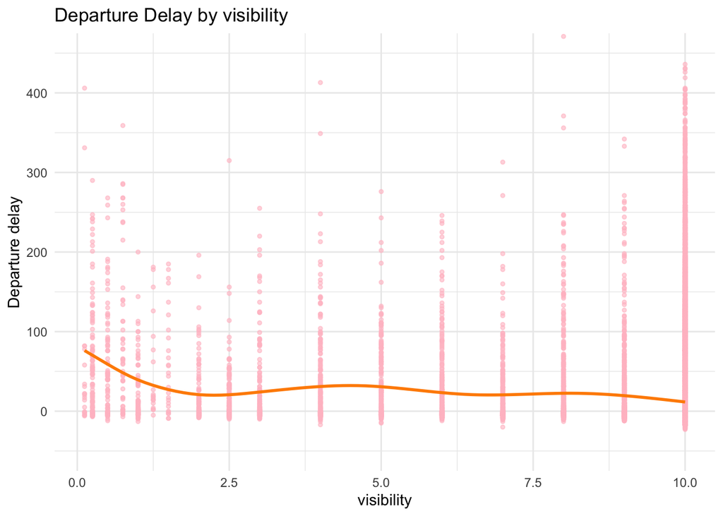

```r
flight_weather |>
  drop_na(dep_delay, visib) |>
  ggplot(aes(x = visib, y = dep_delay)) +
  geom_point(
    color = "pink",
    alpha = 0.6,
    size = 1
  ) +
  geom_smooth(
    color = "darkorange",
    se = FALSE
  ) +
  coord_cartesian(ylim = c(-50, 450)) +
  labs(
    title = "Departure Delay by visibility",
    x = "visibility",
    y = "Departure delay"
  ) +
  theme_minimal()
```